# **Milestone 1**

## **Data Dictionary**

**S.No.** : Serial Number

**Name** : Name of the car which includes Brand name and Model name

**Location** : The location in which the car is being sold or is available for purchase (Cities)

**Year** : Manufacturing year of the car

**Kilometers_driven** : The total kilometers driven in the car by the previous owner(s) in KM.

**Fuel_Type** : The type of fuel used by the car. (Petrol, Diesel, Electric, CNG, LPG)

**Transmission** : The type of transmission used by the car. (Automatic / Manual)

**Owner** : Type of ownership

**Mileage** : The standard mileage offered by the car company in kmpl or km/kg

**Engine** : The displacement volume of the engine in CC.

**Power** : The maximum power of the engine in bhp.

**Seats** : The number of seats in the car.

**New_Price** : The price of a new car of the same model in INR 100,000

**Price** : The price of the used car in INR 100,000 (**Target Variable**)

## **Important Notes**

- This notebook can be considered a guide to refer to while solving the problem. The evaluation will be as per the Rubric shared for each Milestone. Unlike previous courses, it does not follow the pattern of the graded questions in different sections. This notebook will give you a direction on what steps need to be taken in order to get a viable solution to the problem. Please note that this is just one way of doing this. There can be other 'creative' ways to solve the problem and we urge you to feel free and explore them as an 'optional' exercise.
- In the notebook, there are markdown cells called - Observations and Insights. It is a good practice to provide observations and extract insights from the outputs.
- The naming convention for different variables can vary. Please consider the code provided in this notebook as a sample code.
- All the outputs in the notebook are just for reference and can be different if you follow a different approach.
- There are sections called **Think About It** in the notebook that will help you get a better understanding of the reasoning behind a particular technique/step. Interested learners can take alternative approaches if they wish to explore different techniques.

# **Milestone 1**

### **Loading libraries**

```python
#Import required libraries
import pandas as pd
import numpy as np

import matplotlib.pyplot as plt
import seaborn as sns

#to ignore warnings
import warnings
warnings.filterwarnings('ignore')

# Remove the limit from the number of displayed columns and rows. It helps to see the entire dataframe while printing it
pd.set_option("display.max_columns", None)
# pd.set_option('display.max_rows', None)
pd.set_option("display.max_rows", 200)
```

### **Let us load the data**

```python
data = pd.read_csv("used_cars.csv")
```

### **Understand the data by observing a few rows**

```python
# View first 5 rows
data.head()
```

|  | S.No. | Name | Location | Year | Kilometers_Driven | Fuel_Type | Transmission | Owner_Type | Mileage | Engine | Power | Seats | New_price | Price |
| --- | --- | --- | --- | --- | --- | --- | --- | --- | --- | --- | --- | --- | --- | --- |
| 0 | 0 | Maruti Wagon R LXI CNG | Mumbai | 2010 | 72000 | CNG | Manual | First | 26.60 | 998.0 | 58.16 | 5.0 | NaN | 1.75 |
| 1 | 1 | Hyundai Creta 1.6 CRDi SX Option | Pune | 2015 | 41000 | Diesel | Manual | First | 19.67 | 1582.0 | 126.20 | 5.0 | NaN | 12.50 |
| 2 | 2 | Honda Jazz V | Chennai | 2011 | 46000 | Petrol | Manual | First | 18.20 | 1199.0 | 88.70 | 5.0 | 8.61 | 4.50 |
| 3 | 3 | Maruti Ertiga VDI | Chennai | 2012 | 87000 | Diesel | Manual | First | 20.77 | 1248.0 | 88.76 | 7.0 | NaN | 6.00 |
| 4 | 4 | Audi A4 New 2.0 TDI Multitronic | Coimbatore | 2013 | 40670 | Diesel | Automatic | Second | 15.20 | 1968.0 | 140.80 | 5.0 | NaN | 17.74 |

```python
# View last 5 rows Hint: Use tail() method
data.tail()
```

|  | S.No. | Name | Location | Year | Kilometers_Driven | Fuel_Type | Transmission | Owner_Type | Mileage | Engine | Power | Seats | New_price | Price |
| --- | --- | --- | --- | --- | --- | --- | --- | --- | --- | --- | --- | --- | --- | --- |
| 7248 | 7248 | Volkswagen Vento Diesel Trendline | Hyderabad | 2011 | 89411 | Diesel | Manual | First | 20.54 | 1598.0 | 103.6 | 5.0 | NaN | NaN |
| 7249 | 7249 | Volkswagen Polo GT TSI | Mumbai | 2015 | 59000 | Petrol | Automatic | First | 17.21 | 1197.0 | 103.6 | 5.0 | NaN | NaN |
| 7250 | 7250 | Nissan Micra Diesel XV | Kolkata | 2012 | 28000 | Diesel | Manual | First | 23.08 | 1461.0 | 63.1 | 5.0 | NaN | NaN |
| 7251 | 7251 | Volkswagen Polo GT TSI | Pune | 2013 | 52262 | Petrol | Automatic | Third | 17.20 | 1197.0 | 103.6 | 5.0 | NaN | NaN |
| 7252 | 7252 | Mercedes-Benz E-Class 2009-2013 E 220 CDI Avan... | Kochi | 2014 | 72443 | Diesel | Automatic | First | 10.00 | 2148.0 | 170.0 | 5.0 | NaN | NaN |

#### **Observations and Insights:**

- We can remove column S.No. as it adds no value to our analysis
- null values on price and new price, would be important to have a look at the number of missing values

### **Let us check the data types and and missing values of each column**

```python
# Check the datatypes of each column. Hint: Use info() method
data.info()
```

```
<class 'pandas.core.frame.DataFrame'>
RangeIndex: 7253 entries, 0 to 7252
Data columns (total 14 columns):
 #   Column             Non-Null Count  Dtype
---  ------             --------------  -----
 0   S.No.              7253 non-null   int64
 1   Name               7253 non-null   object
 2   Location           7253 non-null   object
 3   Year               7253 non-null   int64
 4   Kilometers_Driven  7253 non-null   int64
 5   Fuel_Type          7253 non-null   object
 6   Transmission       7253 non-null   object
 7   Owner_Type         7253 non-null   object
 8   Mileage            7251 non-null   float64
 9   Engine             7207 non-null   float64
 10  Power              7078 non-null   float64
 11  Seats              7200 non-null   float64
 12  New_price          1006 non-null   float64
 13  Price              6019 non-null   float64
dtypes: float64(6), int64(3), object(5)
memory usage: 793.4+ KB
```

```python
# Check total number of missing values of each column. Hint: Use isnull() method
data.isnull().sum()
```

```
S.No.                   0
Name                    0
Location                0
Year                    0
Kilometers_Driven       0
Fuel_Type               0
Transmission            0
Owner_Type              0
Mileage                 2
Engine                 46
Power                 175
Seats                  53
New_price            6247
Price                1234
dtype: int64
```

#### **Observations and Insights:**

- We have a total of 14 columns and 7253 rows
- price and new price have many missing values, especially new price has a heavy number cars that are missing info on new price

We can observe that `S.No.` has no null values. Also the number of unique values are equal to the number of observations. So, `S.No.` looks like an index for the data entry and such a column would not be useful in providing any predictive power for our analysis. Hence it can be dropped.

```python
# Remove S.No. column from data. Hint: Use inplace = True
data.drop(columns="S.No.", inplace=True)
```

## **Exploratory Data Analysis**

### **Let us now explore the summary statistics of numerical variables**

```python
# Explore basic summary statistics of numeric variables. Hint: Use describe() method.
data.describe().T
```

|  | count | mean | std | min | 25% | 50% | 75% | max |
| --- | --- | --- | --- | --- | --- | --- | --- | --- |
| Year | 7253.0 | 2013.365366 | 3.254421 | 1996.00 | 2011.000 | 2014.00 | 2016.0000 | 2019.00 |
| Kilometers_Driven | 7253.0 | 58699.063146 | 84427.720583 | 171.00 | 34000.000 | 53416.00 | 73000.0000 | 6500000.00 |
| Mileage | 7251.0 | 18.141580 | 4.562197 | 0.00 | 15.170 | 18.16 | 21.1000 | 33.54 |
| Engine | 7207.0 | 1616.573470 | 595.285137 | 72.00 | 1198.000 | 1493.00 | 1968.0000 | 5998.00 |
| Power | 7078.0 | 112.765214 | 53.493553 | 34.20 | 75.000 | 94.00 | 138.1000 | 616.00 |
| Seats | 7200.0 | 5.280417 | 0.809277 | 2.00 | 5.000 | 5.00 | 5.0000 | 10.00 |
| New_price | 1006.0 | 22.779692 | 27.759344 | 3.91 | 7.885 | 11.57 | 26.0425 | 375.00 |
| Price | 6019.0 | 9.479468 | 11.187917 | 0.44 | 3.500 | 5.64 | 9.9500 | 160.00 |

#### **Observations and Insights:**

- total number of cars at 7253
- Most expensive used car is 16,000,000 and most expensive new price for car was 37,500,000 IND
- mean of year manufactured is 2013 with standard deviation of 3.25
- minimum value for certain cars for mileage was 0, which basically means the car wouldn't be able to move, very unlikely that a car company would try to market a car that does not move.
- new price and price is skewed to the right

### **Let us also explore the summary statistics of all categorical variables and the number of unique observations in each category**

```python
# Explore basic summary statistics of categorical variables. Hint: Use the argument include=['object']
data.nunique()
```

```
Name                 2041
Location               11
Year                   23
Kilometers_Driven    3660
Fuel_Type               5
Transmission            2
Owner_Type              4
Mileage               438
Engine                150
Power                 383
Seats                   8
New_price             625
Price                1373
dtype: int64
```

**Number of unique observations in each category**

```python
cat_cols=data.select_dtypes(include=['object']).columns

for column in cat_cols:
    print("For column:",column)
    print(data[column].value_counts(normalize=True))
    print('-'*50)
```

```
For column: Name
Mahindra XUV500 W8 2WD                  0.007583
Maruti Swift VDI                        0.006756
Maruti Swift Dzire VDI                  0.005791
Honda City 1.5 S MT                     0.005377
Maruti Swift VDI BSIV                   0.005101
                                          ...
Chevrolet Beat LT Option                0.000138
Skoda Rapid 1.6 MPI AT Elegance Plus    0.000138
Ford EcoSport 1.5 TDCi Ambiente         0.000138
Hyundai i10 Magna 1.1 iTech SE          0.000138
Hyundai Elite i20 Magna Plus            0.000138
Name: Name, Length: 2041, dtype: float64
--------------------------------------------------
For column: Location
Mumbai        0.130842
Hyderabad     0.120778
Coimbatore    0.106439
Kochi         0.106439
Pune          0.105474
Delhi         0.090997
Kolkata       0.090170
Chennai       0.081484
Jaipur        0.068799
Bangalore     0.060665
Ahmedabad     0.037915
Name: Location, dtype: float64
--------------------------------------------------
For column: Fuel_Type
Diesel      0.531091
Petrol      0.458431
CNG         0.008548
LPG         0.001654
Electric    0.000276
Name: Fuel_Type, dtype: float64
--------------------------------------------------
For column: Transmission
Manual       0.717496
Automatic    0.282504
Name: Transmission, dtype: float64
--------------------------------------------------
For column: Owner_Type
First             0.820626
Second            0.158831
Third             0.018889
Fourth & Above    0.001654
Name: Owner_Type, dtype: float64
--------------------------------------------------
```

#### **Observations and Insights:**

- 72% cars in india are manual cars
- 82% of cars are being sold after the first owner
- 53% are diesel and 46% are petrol cars, the rest are a miniscule number
- most cars are from mumbai
- in terms of car name there is a wide range and spreadout, though the mahindra xuv500 w8 2wd is close to 1% of the total number of cars being supplied

**Think About It**:

- We could observe from summary statistics that kilometers_driven has extreme values. Can we look at the manufactured year for cars with extreme values for kilometers_driven?
- Also, we could observe the feature mileage has values zero. Can the mileage of a car be zero?

**Let's explore the two points mentioned above**

**Check Kilometers_Driven extreme values**

```python
#Sort the dataset in 'descending' order using the feature 'Kilometers_Driven'
data.sort_values(by='Kilometers_Driven', ascending=False).head(10)
```

|  | Name | Location | Year | Kilometers_Driven | Fuel_Type | Transmission | Owner_Type | Mileage | Engine | Power | Seats | New_price | Price |
| --- | --- | --- | --- | --- | --- | --- | --- | --- | --- | --- | --- | --- | --- |
| 2328 | BMW X5 xDrive 30d M Sport | Chennai | 2017 | 6500000 | Diesel | Automatic | First | 15.97 | 2993.0 | 258.00 | 5.0 | NaN | 65.00 |
| 340 | Skoda Octavia Ambition Plus 2.0 TDI AT | Kolkata | 2013 | 775000 | Diesel | Automatic | First | 19.30 | 1968.0 | 141.00 | 5.0 | NaN | 7.50 |
| 1860 | Volkswagen Vento Diesel Highline | Chennai | 2013 | 720000 | Diesel | Manual | First | 20.54 | 1598.0 | 103.60 | 5.0 | NaN | 5.90 |
| 358 | Hyundai i10 Magna 1.2 | Chennai | 2009 | 620000 | Petrol | Manual | First | 20.36 | 1197.0 | 78.90 | 5.0 | NaN | 2.70 |
| 2823 | Volkswagen Jetta 2013-2015 2.0L TDI Highline AT | Chennai | 2015 | 480000 | Diesel | Automatic | First | 16.96 | 1968.0 | 138.03 | 5.0 | NaN | 13.00 |
| 3092 | Honda City i VTEC SV | Kolkata | 2015 | 480000 | Petrol | Manual | First | 17.40 | 1497.0 | 117.30 | 5.0 | NaN | 5.00 |
| 4491 | Hyundai i20 Magna Optional 1.2 | Bangalore | 2013 | 445000 | Petrol | Manual | First | 18.50 | 1197.0 | 82.90 | 5.0 | NaN | 4.45 |
| 6921 | Maruti Swift Dzire Tour LDI | Jaipur | 2012 | 350000 | Diesel | Manual | First | 23.40 | 1248.0 | 74.00 | 5.0 | NaN | NaN |
| 3649 | Tata Indigo LS | Jaipur | 2008 | 300000 | Diesel | Manual | First | 17.00 | 1405.0 | 70.00 | 5.0 | NaN | 1.00 |
| 1528 | Toyota Innova 2.5 G (Diesel) 8 Seater BS IV | Hyderabad | 2005 | 299322 | Diesel | Manual | First | 12.80 | 2494.0 | 102.00 | 8.0 | NaN | 4.00 |

#### **Observations and Insights: **_****

In the first row, a car manufactured as recently as 2017 having been driven 6500000 km is almost impossible. It can be considered as data entry error and so we can remove this value/entry from data.

```python
# Removing the 'row' at index 2328 from the data. Hint: use the argument inplace=True
data.drop(labels=[2328],axis=0,inplace=True)
```

**Check Mileage extreme values**

```python
#Sort the dataset in 'ascending' order using the feature 'Mileage'
data.sort_values(by='Mileage',ascending=True).head(10)
```

|  | Name | Location | Year | Kilometers_Driven | Fuel_Type | Transmission | Owner_Type | Mileage | Engine | Power | Seats | New_price | Price |
| --- | --- | --- | --- | --- | --- | --- | --- | --- | --- | --- | --- | --- | --- |
| 2597 | Hyundai Santro Xing XP | Pune | 2007 | 70000 | Petrol | Manual | First | 0.0 | 1086.0 | NaN | 5.0 | NaN | 1.12 |
| 2343 | Hyundai Santro AT | Hyderabad | 2006 | 74483 | Petrol | Automatic | First | 0.0 | 999.0 | NaN | 5.0 | NaN | 2.30 |
| 5270 | Honda City 1.5 GXI | Bangalore | 2002 | 53000 | Petrol | Manual | Second | 0.0 | NaN | NaN | NaN | NaN | 1.85 |
| 424 | Volkswagen Jetta 2007-2011 1.9 L TDI | Hyderabad | 2010 | 42021 | Diesel | Manual | First | 0.0 | 1968.0 | NaN | 5.0 | NaN | 5.45 |
| 6857 | Land Rover Freelander 2 TD4 SE | Mumbai | 2011 | 87000 | Diesel | Automatic | First | 0.0 | 2179.0 | 115.0 | 5.0 | NaN | NaN |
| 443 | Hyundai Santro GLS I - Euro I | Coimbatore | 2012 | 50243 | Petrol | Manual | First | 0.0 | 1086.0 | NaN | 5.0 | NaN | 3.35 |
| 5119 | Hyundai Santro Xing XP | Kolkata | 2008 | 45500 | Petrol | Manual | Second | 0.0 | 1086.0 | NaN | 5.0 | NaN | 1.17 |
| 5022 | Land Rover Freelander 2 TD4 SE | Hyderabad | 2013 | 46000 | Diesel | Automatic | Second | 0.0 | 2179.0 | 115.0 | 5.0 | NaN | 26.00 |
| 5016 | Land Rover Freelander 2 TD4 HSE | Delhi | 2013 | 72000 | Diesel | Automatic | First | 0.0 | 2179.0 | 115.0 | 5.0 | NaN | 15.50 |
| 2542 | Hyundai Santro GLS II - Euro II | Bangalore | 2011 | 65000 | Petrol | Manual | Second | 0.0 | NaN | NaN | NaN | NaN | 3.15 |

```python
data.sort_values(by='Mileage',ascending=True)
```

|  | Name | Location | Year | Kilometers_Driven | Fuel_Type | Transmission | Owner_Type | Mileage | Engine | Power | Seats | New_price | Price |
| --- | --- | --- | --- | --- | --- | --- | --- | --- | --- | --- | --- | --- | --- |
| 2597 | Hyundai Santro Xing XP | Pune | 2007 | 70000 | Petrol | Manual | First | 0.00 | 1086.0 | NaN | 5.0 | NaN | 1.12 |
| 2343 | Hyundai Santro AT | Hyderabad | 2006 | 74483 | Petrol | Automatic | First | 0.00 | 999.0 | NaN | 5.0 | NaN | 2.30 |
| 5270 | Honda City 1.5 GXI | Bangalore | 2002 | 53000 | Petrol | Manual | Second | 0.00 | NaN | NaN | NaN | NaN | 1.85 |
| 424 | Volkswagen Jetta 2007-2011 1.9 L TDI | Hyderabad | 2010 | 42021 | Diesel | Manual | First | 0.00 | 1968.0 | NaN | 5.0 | NaN | 5.45 |
| 6857 | Land Rover Freelander 2 TD4 SE | Mumbai | 2011 | 87000 | Diesel | Automatic | First | 0.00 | 2179.0 | 115.00 | 5.0 | NaN | NaN |
| ... | ... | ... | ... | ... | ... | ... | ... | ... | ... | ... | ... | ... | ... |
| 3129 | Maruti Wagon R CNG LXI | Delhi | 2014 | 74663 | CNG | Manual | First | 33.54 | 998.0 | 67.04 | 5.0 | 5.35 | 3.25 |
| 2059 | Maruti Wagon R CNG LXI | Mumbai | 2013 | 54000 | CNG | Manual | First | 33.54 | 998.0 | 67.04 | 5.0 | 5.58 | 3.05 |
| 2371 | Maruti Wagon R CNG LXI | Pune | 2014 | 29202 | CNG | Manual | First | 33.54 | 998.0 | 67.04 | 5.0 | 5.54 | 3.90 |
| 4446 | Mahindra E Verito D4 | Chennai | 2016 | 50000 | Electric | Automatic | First | NaN | 72.0 | 41.00 | 5.0 | 13.58 | 13.00 |
| 4904 | Toyota Prius 2009-2016 Z4 | Mumbai | 2011 | 44000 | Electric | Automatic | First | NaN | 1798.0 | 73.00 | 5.0 | NaN | 12.75 |

7252 rows × 13 columns

#### **Observations**

- Mileage of cars can not be 0, so we should treat 0's as missing values. We will do it in the Feature Engineering part

## **Univariate Analysis**

Univariate analysis is used to explore each variable in a data set, separately. It looks at the range of values, as well as the central tendency of the values. It can be done for both numerical and categorical variables.

## **1. Univariate Analysis - Numerical Data**

Histograms and box plots help to visualize and describe numerical data. We use box plot and histogram to analyse the numerical columns.

```python
# Let us write a function that will help us create a boxplot and histogram for any input numerical variable.
# This function takes the numerical column as the input and returns the boxplots and histograms for the variable.

def histogram_boxplot(feature, figsize=(15,10), bins = None):
    """ Boxplot and histogram combined
    feature: 1-d feature array
    figsize: size of fig (default (9,8))
    bins: number of bins (default None / auto)
    """
    f2, (ax_box2, ax_hist2) = plt.subplots(nrows = 2, # Number of rows of the subplot grid= 2
                                           sharex = True, # x-axis will be shared among all subplots
                                           gridspec_kw = {"height_ratios": (.25, .75)},
                                           figsize = figsize
                                           ) # creating the 2 subplots
    sns.boxplot(feature, ax=ax_box2, showmeans=True, color='violet') # boxplot will be created and a star will indicate the mean value of the column
    sns.distplot(feature, kde=F, ax=ax_hist2, bins=bins,palette="winter") if bins else sns.distplot(feature, kde=False, ax=ax_hist2) # For histogram
    ax_hist2.axvline(np.mean(feature), color='green', linestyle='--') # Add mean to the histogram
    ax_hist2.axvline(np.median(feature), color='black', linestyle='-') # Add median to the histogram
```

#### Let us plot histogram and box-plot for the feature 'Kilometers_Driven' to understand the distribution and outliers, if any.

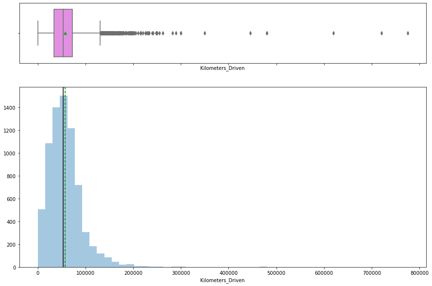

```python
#Plot histogram and box-plot for 'Kilometers_Driven'
histogram_boxplot(data['Kilometers_Driven'])
```

**Think About It**: Kilometers_Driven is highly right-skewed. Can we use Log transformation of the feature to reduce/remove the skewness? Why can't we keep skewed data?

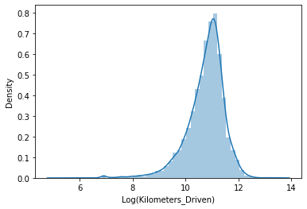

```python
#Log transformation of the feature 'Kilometers_Driven'
sns.distplot(np.log(data["Kilometers_Driven"]), axlabel="Log(Kilometers_Driven)");
```

#### **Observations and Insights:**

- log of km driven is now skewed more to the left

```python
### We can add a transformed kilometers_driven feature in data
data["kilometers_driven_log"] = np.log(data["Kilometers_Driven"])
```

**Note:** Like Kilometers_Driven, the distribution of Price is also highly skewed, we can use log transformation on this column to see if that helps normalize the distribution. And add the transformed variable into the dataset. You can name the variable as **'price_log'**

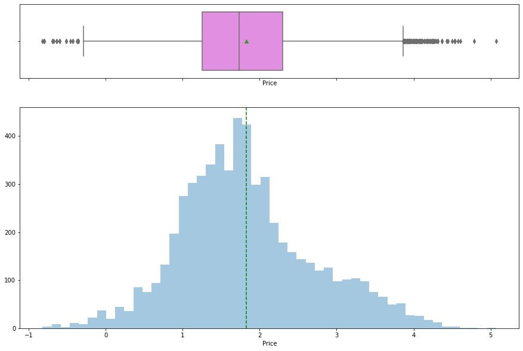

```python
# Plot histogram and box-plot for 'Price'
histogram_boxplot(np.log(data['Price']))
```

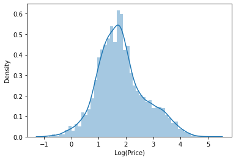

```python
# Log transformation of the feature 'Price'
sns.distplot(np.log(data["Price"]), axlabel="Log(Price)");
```

```python
# We can Add a transformed Price feature in data
data["price_log"] = np.log(data["Price"])
```

#### **Note:** Try plotting histogram and box-plot for different numerical features and understand how the data looks like.

#### **Observations and Insights for all the plots:**

- originally the histogram and boxplot was extremely skewed to the right
- meaning most of the vehicles were at the lower end of the spectrum, making sense since they are older used vehicles.
- log of price seems to remove the skew and show the form closer to a normal distribution

## **2. Univariate analysis - Categorical Data**

```python
# Let us write a function that will help us create barplots that indicate the percentage for each category.
# This function takes the categorical column as the input and returns the barplots for the variable.

def perc_on_bar(z):
    '''
    plot
    feature: categorical feature
    the function won't work if a column is passed in hue parameter
    '''

    total = len(data[z]) # length of the column
    plt.figure(figsize=(15,5))
    ax = sns.countplot(data[z],palette='Paired',order = data[z].value_counts().index)
    for p in ax.patches:
        percentage = '{:.1f}%'.format(100 * p.get_height()/total) # percentage of each class of the category
        x = p.get_x() + p.get_width() / 2 - 0.05 # width of the plot
        y = p.get_y() + p.get_height()           # hieght of the plot

        ax.annotate(percentage, (x, y), size = 12) # annotate the percantage

    plt.show() # show the plot
```

#### Let us plot barplot for the variable location. It will be helpful to know the number of percentage of cars from each city.

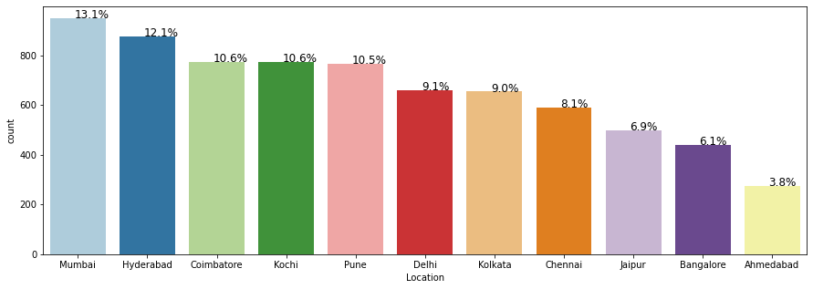

```python
#Bar Plot for 'Location'
perc_on_bar('Location')
```

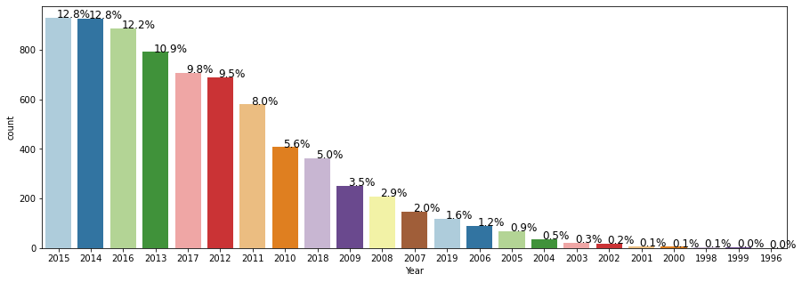

```python
perc_on_bar('Year')
```

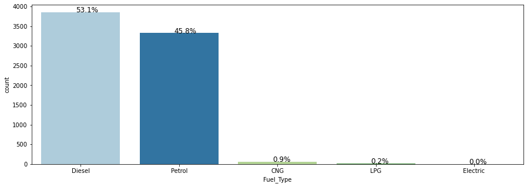

```python
perc_on_bar('Fuel_Type')
```

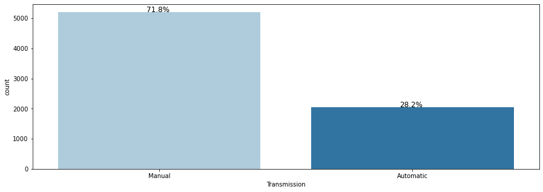

```python
perc_on_bar('Transmission')
```

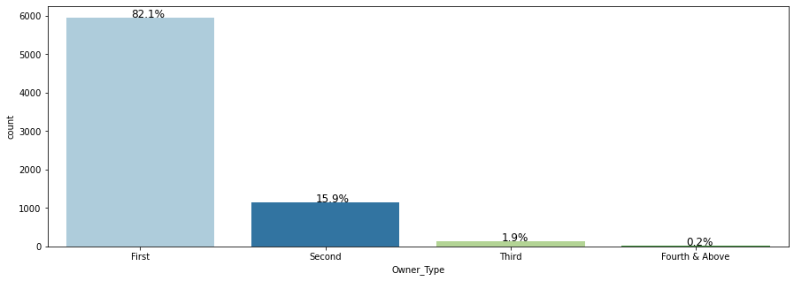

```python
perc_on_bar('Owner_Type')
```

#### **Note:** Explore for other variables like Year, Fuel_Type, Transmission, Owner_Type`

#### **Observations and Insights from all plots:**

- Mumbai has the highest % of vehicles allocated for used cars followed by hyderabad and coimbatore and kochi, pune.
- on the other hand Ahmedabad had the lowest at 3.8% might be an indicator of comparatively lower population.
- would be interesting to the absolute number of used cars divided by population of the city which might show interested insights as to which city has the highest car per capita

## **Bivariate Analysis**

### **1. Scatter plot**

A scatter plot allows us to see relationships between two variables.

**Note: Use log transformed values 'kilometers_driven_log' and 'price_log'**

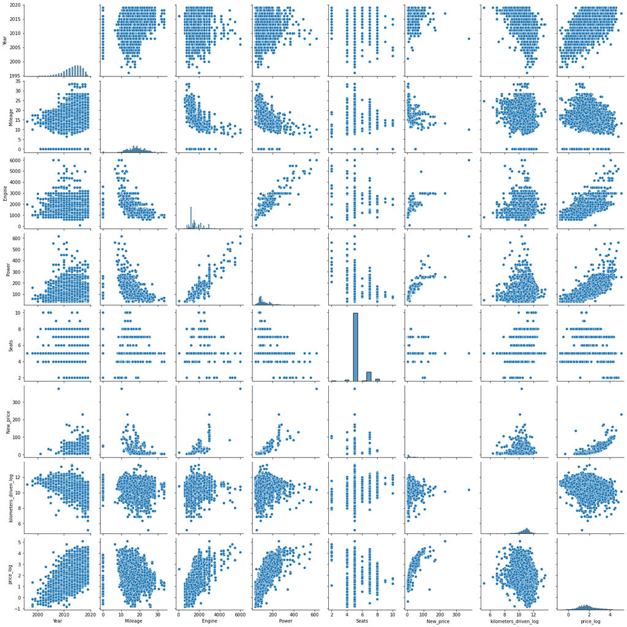

```python
#Let us plot pair plot for the variables 'year' and 'price_log'
#data.plot(x='price_log', y='Year', style='o')
sns.pairplot(data.drop(['Kilometers_Driven','Price'],axis=1))
plt.show()
```

**Note:** Try to explore different combinations of independent variables and dependent variable. Understand the relationship between all variables.

### **2. Heat map**

Heat map shows a 2D correlation matrix between two discrete features

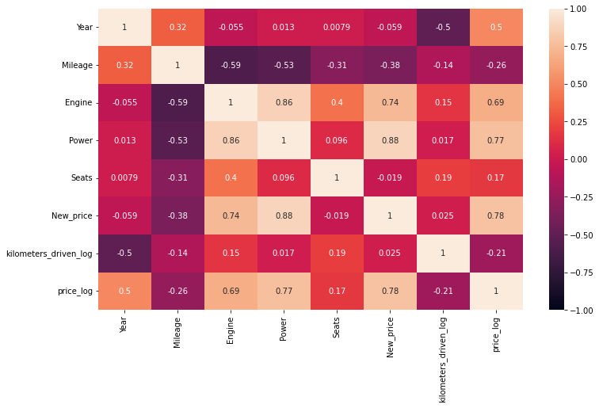

```python
#We can include the log transformation values and drop the original skewed data columns
plt.figure(figsize=(12, 7))
sns.heatmap(data.drop(["Price","Kilometers_Driven"],axis=1).corr(), annot = True, vmin = -1, vmax = 1)
plt.show()
```

**Observations and Insights:**

- engine, power have a negative correlation against mileage. the more mileage less engine and less power
- where as power and engine are highly positively correlated with each other.
- price vs engine, and power are also highly positively correlated. new price and used car price are also highly correlated.
- power and engine are still pretty good indicators for used car price

### **3. Box plot**

```python
# Let us write a function that will help us create boxplot w.r.t Price for any input categorical variable.
# This function takes the categorical column as the input and returns the boxplots for the variable.
def boxplot(z):
    plt.figure(figsize=(12, 5)) #setting size of boxplot
    sns.boxplot(x=z, y=data['Price']) # defining x and y
    plt.show()
    plt.figure(figsize=(12, 5))
    plt.title('Without Outliers')
    sns.boxplot(x=z, y=data['Price'],showfliers=False) #turning off the outliers
    plt.show()
```

#### Let us now plot bivariate analysis of target variable with a categorical variable 'Location'

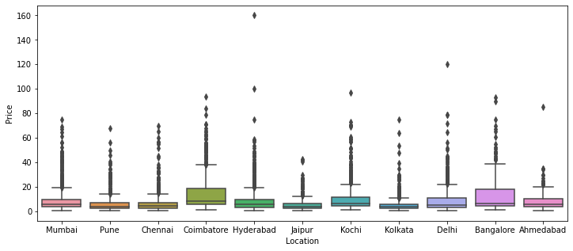

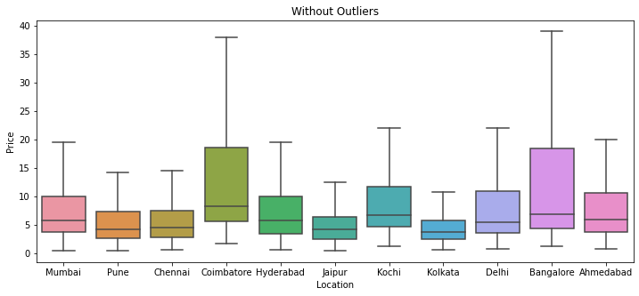

```python
#Box Plot:Price vs Location
boxplot(data['Location'])
```

**Note:** Explore by plotting box-plots for target variable and the other categorical variables like Fuel_Type, transmission, Owner_type.

**Observations and Insights for all plots**

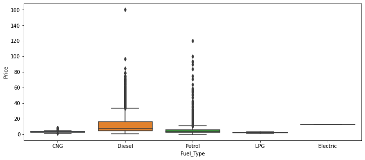

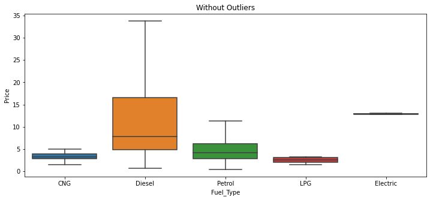

```python
boxplot(data['Fuel_Type'])
```

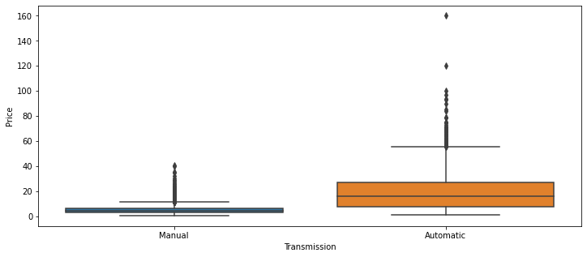

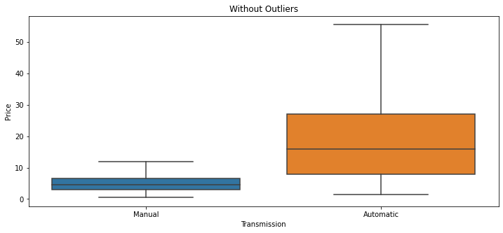

```python
boxplot(data['Transmission'])
```

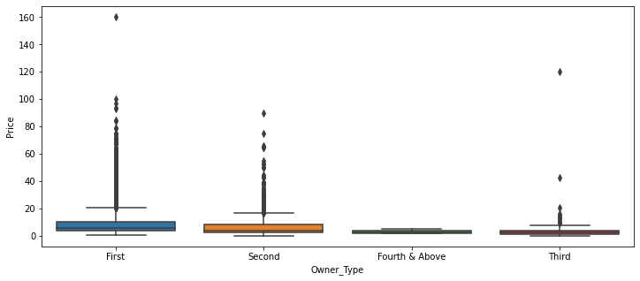

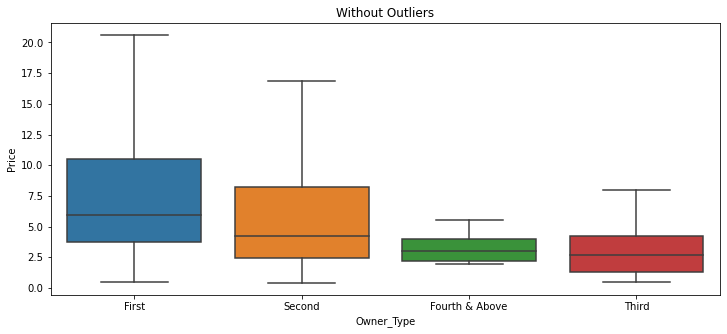

```python
boxplot(data['Owner_Type'])
```

### **Feature engineering**

**Think about it:** The `Name` column in the current format might not be very useful in our analysis. Since the name contains both the brand name and the model name of the vehicle, the column would have too many unique values to be useful in prediction. Can we extract that information from that column?

```python
data["Name"].nunique()
```

```
2041
```

- **Hint:** With 2041 unique names, car names are not going to be great predictors of the price in our current data. But we can process this column to extract important information for example brand name.

```python
#Extract brand names
data["Brand"]=data["Name"].apply(lambda x:x.split(" ")[0].lower())

#check the data
data["Brand"].value_counts()
```

```
maruti           1444
hyundai          1340
honda             743
toyota            507
mercedes-benz     380
volkswagen        374
ford              351
mahindra          331
bmw               311
audi              285
tata              228
skoda             202
renault           170
chevrolet         151
nissan            117
land               67
jaguar             48
fiat               38
mitsubishi         36
mini               31
volvo              28
porsche            19
jeep               19
datsun             17
isuzu               5
force               3
bentley             2
smart               1
ambassador          1
lamborghini         1
hindustan           1
opelcorsa           1
Name: Brand, dtype: int64
```

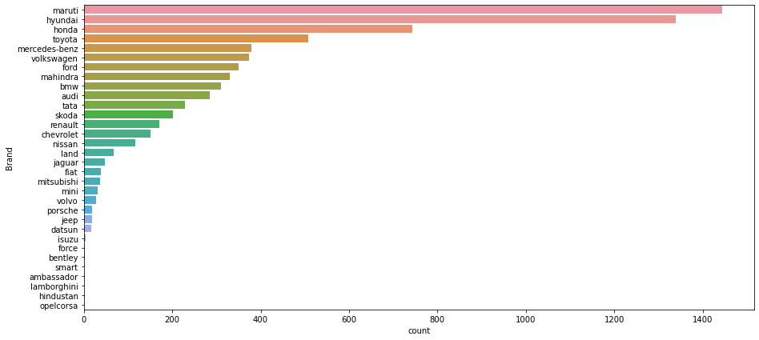

```python
plt.figure(figsize=(15,7))
sns.countplot(y="Brand",data=data,order=data["Brand"].value_counts().index)
plt.show()
```

#### **Observations and Insights: **_****

- coimatore and bangalore have wide ranges of min and max price of cars
- most frequent brands are maruti and hyundai
- could it be that these areas are more affluent than others?
- places like kolkata seem to have a more concentrated range of cars
- in terms of fuel cng ,electric, and lpg had a very small spread where as diesel had the widest spread in price. this could be caused by low-end vehicles using vehicles vs vehicles like bmw or mercendes that have diesel engines
- in terms of ownership. first owner vehicles had the largest spread followed by second, third, and so on. Number of ownership seems to be a good indicator of how it would be perceived in price. first owner also means that depending on how the first owner drove it price can be somewhat be a good predictor of the vehicle

```python
data["Model"]=data["Name"].apply(lambda x:x.split(" ")[1].lower())

data["Model"].value_counts()
```

```
swift      418
city       318
i20        303
innova     203
verna      200
          ...
fortwo       1
redi         1
e            1
mustang      1
1.4gsi       1
Name: Model, Length: 218, dtype: int64
```

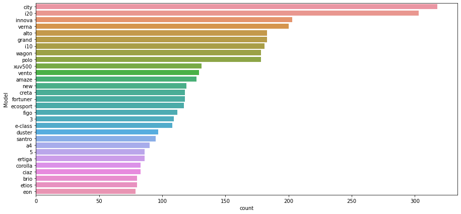

```python
plt.figure(figsize=(15,7))
sns.countplot(y="Model",data=data,order=data["Model"].value_counts().index[1:30])
```

- it is clear that the data set has luxury and budget-friendly vehicles
- we now have a better understanding of brand names and models of our vehicles

```python
data.groupby(["Brand"])["Price"].mean().sort_values(ascending=False)
```

```
Brand
lamborghini      120.000000
bentley           59.000000
porsche           48.348333
land              39.259500
jaguar            37.632250
mini              26.896923
mercedes-benz     26.809874
audi              25.537712
bmw               25.093684
volvo             18.802857
jeep              18.718667
isuzu             14.696667
toyota            11.580024
mitsubishi        11.058889
force              9.333333
mahindra           8.045919
skoda              7.559075
ford               6.889400
renault            5.799034
honda              5.411743
hyundai            5.343433
volkswagen         5.307270
nissan             4.738352
maruti             4.517267
tata               3.562849
fiat               3.269286
datsun             3.049231
chevrolet          3.044463
smart              3.000000
ambassador         1.350000
hindustan               NaN
opelcorsa               NaN
Name: Price, dtype: float64
```

- the outcome is similar to what we know in the real world and the prices associated with the vehicles

### **Missing value treatment**

# data.to_csv("new_data.csv",index=False)

```python
# Now check the missing values of each column. Hint: Use isnull() method
data.isnull().sum()
```

```
Name                        0
Location                    0
Year                        0
Kilometers_Driven           0
Fuel_Type                   0
Transmission                0
Owner_Type                  0
Mileage                     2
Engine                     46
Power                     175
Seats                      53
New_price                6246
Price                    1234
kilometers_driven_log       0
price_log                1234
Brand                       0
Model                       0
dtype: int64
```

#### **Observations and Insights:**

- many missing values in new price as well as used car price
- some missing values in seats, power, engine, and mileage

**Missing values in Seats**

```python
data[data['Seats'].isnull()]
```

|  | Name | Location | Year | Kilometers_Driven | Fuel_Type | Transmission | Owner_Type | Mileage | Engine | Power | Seats | New_price | Price | kilometers_driven_log | price_log | Brand | Model |
| --- | --- | --- | --- | --- | --- | --- | --- | --- | --- | --- | --- | --- | --- | --- | --- | --- | --- |
| 194 | Honda City 1.5 GXI | Ahmedabad | 2007 | 60006 | Petrol | Manual | First | 0.00 | NaN | NaN | NaN | NaN | 2.95 | 11.002200 | 1.081805 | honda | city |
| 208 | Maruti Swift 1.3 VXi | Kolkata | 2010 | 42001 | Petrol | Manual | First | 16.10 | NaN | NaN | NaN | NaN | 2.11 | 10.645449 | 0.746688 | maruti | swift |
| 229 | Ford Figo Diesel | Bangalore | 2015 | 70436 | Diesel | Manual | First | 0.00 | 1498.0 | 99.0 | NaN | NaN | 3.60 | 11.162460 | 1.280934 | ford | figo |
| 733 | Maruti Swift 1.3 VXi | Chennai | 2006 | 97800 | Petrol | Manual | Third | 16.10 | NaN | NaN | NaN | NaN | 1.75 | 11.490680 | 0.559616 | maruti | swift |
| 749 | Land Rover Range Rover 3.0 D | Mumbai | 2008 | 55001 | Diesel | Automatic | Second | 0.00 | NaN | NaN | NaN | NaN | 26.50 | 10.915107 | 3.277145 | land | rover |
| 1294 | Honda City 1.3 DX | Delhi | 2009 | 55005 | Petrol | Manual | First | 12.80 | NaN | NaN | NaN | NaN | 3.20 | 10.915179 | 1.163151 | honda | city |
| 1327 | Maruti Swift 1.3 ZXI | Hyderabad | 2015 | 50295 | Petrol | Manual | First | 16.10 | NaN | NaN | NaN | NaN | 5.80 | 10.825661 | 1.757858 | maruti | swift |
| 1385 | Honda City 1.5 GXI | Pune | 2004 | 115000 | Petrol | Manual | Second | 0.00 | NaN | NaN | NaN | NaN | 1.50 | 11.652687 | 0.405465 | honda | city |
| 1460 | Land Rover Range Rover Sport 2005 2012 Sport | Coimbatore | 2008 | 69078 | Petrol | Manual | First | 0.00 | NaN | NaN | NaN | NaN | 40.88 | 11.142992 | 3.710641 | land | rover |
| 1917 | Honda City 1.5 EXI | Jaipur | 2005 | 88000 | Petrol | Manual | Second | 13.00 | 1493.0 | 100.0 | NaN | NaN | 1.70 | 11.385092 | 0.530628 | honda | city |
| 2074 | Maruti Swift 1.3 LXI | Pune | 2011 | 24255 | Petrol | Manual | First | 16.10 | NaN | NaN | NaN | NaN | 3.15 | 10.096378 | 1.147402 | maruti | swift |
| 2096 | Hyundai Santro LP zipPlus | Coimbatore | 2004 | 52146 | Petrol | Manual | First | 0.00 | NaN | NaN | NaN | NaN | 1.93 | 10.861803 | 0.657520 | hyundai | santro |
| 2264 | Toyota Etios Liva V | Pune | 2012 | 24500 | Petrol | Manual | Second | 18.30 | NaN | NaN | NaN | NaN | 2.95 | 10.106428 | 1.081805 | toyota | etios |
| 2325 | Maruti Swift 1.3 VXI ABS | Pune | 2015 | 67000 | Petrol | Manual | First | 16.10 | NaN | NaN | NaN | NaN | 4.70 | 11.112448 | 1.547563 | maruti | swift |
| 2335 | Maruti Swift 1.3 VXi | Mumbai | 2007 | 55000 | Petrol | Manual | Second | 16.10 | NaN | NaN | NaN | NaN | 1.75 | 10.915088 | 0.559616 | maruti | swift |
| 2369 | Maruti Estilo LXI | Chennai | 2008 | 56000 | Petrol | Manual | Second | 19.50 | 1061.0 | NaN | NaN | NaN | 1.50 | 10.933107 | 0.405465 | maruti | estilo |
| 2530 | BMW 5 Series 520d Sedan | Kochi | 2014 | 64158 | Diesel | Automatic | First | 18.48 | NaN | NaN | NaN | NaN | 17.89 | 11.069104 | 2.884242 | bmw | 5 |
| 2542 | Hyundai Santro GLS II - Euro II | Bangalore | 2011 | 65000 | Petrol | Manual | Second | 0.00 | NaN | NaN | NaN | NaN | 3.15 | 11.082143 | 1.147402 | hyundai | santro |
| 2623 | BMW 5 Series 520d Sedan | Pune | 2012 | 95000 | Diesel | Automatic | Second | 18.48 | NaN | NaN | NaN | NaN | 18.00 | 11.461632 | 2.890372 | bmw | 5 |
| 2668 | Maruti Swift 1.3 VXi | Kolkata | 2014 | 32986 | Petrol | Manual | First | 16.10 | NaN | NaN | NaN | NaN | 4.24 | 10.403839 | 1.444563 | maruti | swift |
| 2737 | Maruti Wagon R Vx | Jaipur | 2001 | 200000 | Petrol | Manual | First | 12.00 | NaN | NaN | NaN | NaN | 0.70 | 12.206073 | -0.356675 | maruti | wagon |
| 2780 | Hyundai Santro GLS II - Euro II | Pune | 2009 | 100000 | Petrol | Manual | First | 0.00 | NaN | NaN | NaN | NaN | 1.60 | 11.512925 | 0.470004 | hyundai | santro |
| 2842 | Hyundai Santro GLS II - Euro II | Bangalore | 2012 | 43000 | Petrol | Manual | First | 0.00 | NaN | NaN | NaN | NaN | 3.25 | 10.668955 | 1.178655 | hyundai | santro |
| 3272 | BMW 5 Series 520d Sedan | Mumbai | 2008 | 81000 | Diesel | Automatic | Second | 18.48 | NaN | NaN | NaN | NaN | 10.50 | 11.302204 | 2.351375 | bmw | 5 |
| 3404 | Maruti Swift 1.3 VXi | Jaipur | 2006 | 125000 | Petrol | Manual | Fourth & Above | 16.10 | NaN | NaN | NaN | NaN | 2.35 | 11.736069 | 0.854415 | maruti | swift |
| 3520 | BMW 5 Series 520d Sedan | Delhi | 2012 | 90000 | Diesel | Automatic | First | 18.48 | NaN | NaN | NaN | NaN | 14.50 | 11.407565 | 2.674149 | bmw | 5 |
| 3522 | Hyundai Santro GLS II - Euro II | Kochi | 2012 | 66400 | Petrol | Manual | First | 0.00 | NaN | NaN | NaN | NaN | 2.66 | 11.103452 | 0.978326 | hyundai | santro |
| 3800 | Ford Endeavour Hurricane LE | Mumbai | 2012 | 129000 | Diesel | Automatic | First | 12.80 | 2953.0 | NaN | NaN | NaN | 7.00 | 11.767568 | 1.945910 | ford | endeavour |
| 3810 | Honda CR-V AT With Sun Roof | Kolkata | 2013 | 27000 | Petrol | Automatic | First | 14.00 | NaN | NaN | NaN | NaN | 11.99 | 10.203592 | 2.484073 | honda | cr-v |
| 3882 | Maruti Estilo LXI | Kolkata | 2010 | 40000 | Petrol | Manual | Second | 19.50 | 1061.0 | NaN | NaN | NaN | 2.50 | 10.596635 | 0.916291 | maruti | estilo |
| 4011 | Fiat Punto 1.3 Emotion | Pune | 2011 | 45271 | Diesel | Manual | First | 20.30 | NaN | NaN | NaN | NaN | 2.60 | 10.720422 | 0.955511 | fiat | punto |
| 4152 | Land Rover Range Rover 3.0 D | Mumbai | 2003 | 75000 | Diesel | Automatic | Second | 0.00 | NaN | NaN | NaN | NaN | 16.11 | 11.225243 | 2.779440 | land | rover |
| 4229 | Hyundai Santro Xing XG | Bangalore | 2005 | 79000 | Petrol | Manual | Second | 17.00 | NaN | NaN | NaN | NaN | 1.65 | 11.277203 | 0.500775 | hyundai | santro |
| 4577 | BMW 5 Series 520d Sedan | Delhi | 2012 | 72000 | Diesel | Automatic | Third | 18.48 | NaN | NaN | NaN | NaN | 13.85 | 11.184421 | 2.628285 | bmw | 5 |
| 4604 | Honda Jazz Select Edition | Pune | 2011 | 98000 | Petrol | Manual | First | 16.70 | NaN | NaN | NaN | NaN | 3.15 | 11.492723 | 1.147402 | honda | jazz |
| 4697 | Fiat Punto 1.2 Dynamic | Kochi | 2017 | 17941 | Petrol | Manual | First | 15.70 | NaN | NaN | NaN | NaN | 3.93 | 9.794844 | 1.368639 | fiat | punto |
| 4712 | Hyundai Santro Xing XG | Pune | 2003 | 80000 | Petrol | Manual | Second | 17.00 | NaN | NaN | NaN | NaN | 0.90 | 11.289782 | -0.105361 | hyundai | santro |
| 4952 | Fiat Punto 1.4 Emotion | Kolkata | 2010 | 47000 | Petrol | Manual | First | 14.60 | NaN | NaN | NaN | NaN | 1.49 | 10.757903 | 0.398776 | fiat | punto |
| 5015 | Maruti Swift 1.3 VXi | Delhi | 2006 | 63000 | Petrol | Manual | First | 16.10 | NaN | NaN | NaN | NaN | 1.60 | 11.050890 | 0.470004 | maruti | swift |
| 5185 | Maruti Swift 1.3 LXI | Delhi | 2012 | 52000 | Petrol | Manual | First | 16.10 | NaN | NaN | NaN | NaN | 3.65 | 10.858999 | 1.294727 | maruti | swift |
| 5270 | Honda City 1.5 GXI | Bangalore | 2002 | 53000 | Petrol | Manual | Second | 0.00 | NaN | NaN | NaN | NaN | 1.85 | 10.878047 | 0.615186 | honda | city |
| 5893 | Maruti Estilo LXI | Chennai | 2008 | 51000 | Petrol | Manual | Second | 19.50 | 1061.0 | NaN | NaN | NaN | 1.75 | 10.839581 | 0.559616 | maruti | estilo |
| 6042 | Skoda Laura 1.8 TSI Ambition | Bangalore | 2009 | 72000 | Petrol | Manual | Second | 17.50 | NaN | NaN | NaN | NaN | NaN | 11.184421 | NaN | skoda | laura |
| 6541 | Toyota Etios Liva Diesel TRD Sportivo | Bangalore | 2012 | 56600 | Diesel | Manual | First | 23.59 | NaN | NaN | NaN | NaN | NaN | 10.943764 | NaN | toyota | etios |
| 6544 | Hyundai i20 new Sportz AT 1.4 | Bangalore | 2012 | 58000 | Petrol | Automatic | Second | 15.00 | NaN | NaN | NaN | NaN | NaN | 10.968198 | NaN | hyundai | i20 |
| 6633 | Mahindra TUV 300 P4 | Kolkata | 2016 | 27000 | Diesel | Manual | First | 0.00 | NaN | NaN | NaN | NaN | NaN | 10.203592 | NaN | mahindra | tuv |
| 6643 | BMW 5 Series 520d Sedan | Bangalore | 2009 | 150000 | Diesel | Automatic | Second | 18.48 | NaN | NaN | NaN | NaN | NaN | 11.918391 | NaN | bmw | 5 |
| 6651 | Maruti Swift 1.3 VXi | Kolkata | 2015 | 36009 | Petrol | Manual | First | 16.10 | NaN | NaN | NaN | NaN | NaN | 10.491524 | NaN | maruti | swift |
| 6677 | Fiat Punto 1.4 Emotion | Jaipur | 2010 | 65000 | Petrol | Manual | Third | 14.60 | NaN | NaN | NaN | NaN | NaN | 11.082143 | NaN | fiat | punto |
| 6685 | Maruti Swift 1.3 VXi | Pune | 2010 | 115000 | Petrol | Manual | Second | 16.10 | NaN | NaN | NaN | NaN | NaN | 11.652687 | NaN | maruti | swift |
| 6880 | BMW 5 Series 520d Sedan | Chennai | 2009 | 95000 | Diesel | Automatic | Second | 18.48 | NaN | NaN | NaN | NaN | NaN | 11.461632 | NaN | bmw | 5 |
| 6902 | Toyota Etios Liva V | Kochi | 2012 | 59311 | Petrol | Manual | First | 18.30 | NaN | NaN | NaN | NaN | NaN | 10.990550 | NaN | toyota | etios |
| 6957 | Honda Jazz 2020 Petrol | Kochi | 2019 | 11574 | Petrol | Manual | First | 0.00 | 1199.0 | 88.7 | NaN | NaN | NaN | 9.356516 | NaN | honda | jazz |

**Think about it:** Can we somehow use the extracted information from 'Name' column to impute missing values?

**Hint:** Impute these missing values one by one, by taking median number of seats for the particular car, using the Brand and Model name

```python
# Impute missing values in Seats,you can use fillna method in pandas

data["Seats"]=data.groupby(["Brand","Model"])["Seats"].transform(lambda x:x.fillna(x.median()))
```

```python
# Now check total number of missing values of the seat column to verify if they are imputed or not. Hint: Use isnull() method
data['Seats'].isnull()
```

```
0       False
1       False
2       False
3       False
4       False
        ...
7248    False
7249    False
7250    False
7251    False
7252    False
Name: Seats, Length: 7252, dtype: bool
```

```python
data["Seats"]=data["Seats"].fillna(5.0)
```

```python
data.isnull().sum()
```

```
Name                        0
Location                    0
Year                        0
Kilometers_Driven           0
Fuel_Type                   0
Transmission                0
Owner_Type                  0
Mileage                     2
Engine                     46
Power                     175
Seats                       0
New_price                6246
Price                    1234
kilometers_driven_log       0
price_log                1234
Brand                       0
Model                       0
dtype: int64
```

**Missing values for Mileage**

```python
# Impute missing Mileage. For example use can use median or any other methods.
data[data['Mileage'].isnull()]
```

|  | Name | Location | Year | Kilometers_Driven | Fuel_Type | Transmission | Owner_Type | Mileage | Engine | Power | Seats | New_price | Price | kilometers_driven_log | price_log | Brand | Model |
| --- | --- | --- | --- | --- | --- | --- | --- | --- | --- | --- | --- | --- | --- | --- | --- | --- | --- |
| 4446 | Mahindra E Verito D4 | Chennai | 2016 | 50000 | Electric | Automatic | First | NaN | 72.0 | 41.0 | 5.0 | 13.58 | 13.00 | 10.819778 | 2.564949 | mahindra | e |
| 4904 | Toyota Prius 2009-2016 Z4 | Mumbai | 2011 | 44000 | Electric | Automatic | First | NaN | 1798.0 | 73.0 | 5.0 | NaN | 12.75 | 10.691945 | 2.545531 | toyota | prius |

```python
data["Mileage"].fillna(data['Mileage'].median(),inplace=True)
```

```python
data.isnull().sum()
```

```
Name                        0
Location                    0
Year                        0
Kilometers_Driven           0
Fuel_Type                   0
Transmission                0
Owner_Type                  0
Mileage                     0
Engine                     46
Power                     175
Seats                       0
New_price                6246
Price                    1234
kilometers_driven_log       0
price_log                1234
Brand                       0
Model                       0
dtype: int64
```

```python
# Now check total number of missing values of the seat column to verify if they are imputed or not. Hint: Use isnull() method
data[data['Seats'].isnull()]
```

|  | Name | Location | Year | Kilometers_Driven | Fuel_Type | Transmission | Owner_Type | Mileage | Engine | Power | Seats | New_price | Price | kilometers_driven_log | price_log | Brand | Model |
| --- | --- | --- | --- | --- | --- | --- | --- | --- | --- | --- | --- | --- | --- | --- | --- | --- | --- |

**Missing values for Engine**

```python
data['Engine'].fillna(data['Engine'].median(), inplace=True)
```

**Missing values for Power**

```python
data['Power'].fillna(data['Power'].median(), inplace=True)
```

**Missing values for New_price**

```python
data['New_price'].fillna(data['New_price'].median(), inplace=True)
```

```python
data.isnull().sum()
```

```
Name                        0
Location                    0
Year                        0
Kilometers_Driven           0
Fuel_Type                   0
Transmission                0
Owner_Type                  0
Mileage                     0
Engine                      0
Power                       0
Seats                       0
New_price                   0
Price                    1234
kilometers_driven_log       0
price_log                1234
Brand                       0
Model                       0
dtype: int64
```

```python
cars_data=data[data["Price"].notna()]
```

```python
cars_data.isnull().sum()
```

```
Name                     0
Location                 0
Year                     0
Kilometers_Driven        0
Fuel_Type                0
Transmission             0
Owner_Type               0
Mileage                  0
Engine                   0
Power                    0
Seats                    0
New_price                0
Price                    0
kilometers_driven_log    0
price_log                0
Brand                    0
Model                    0
dtype: int64
```

#### **Observations for missing values after imputing:**

- median seems to be the best number to replace because it is more robust.

```python
data.to_csv("new_data.csv",index=False)
```

## **Proposed approach**

- **Potential techniques -** What different techniques should be explored?
- **Overall solution design -** What is the potential solution design?
- **Measures of success -** What are the key measures of success?

# **Milestone 2**

## **Model Building**

1. What we want to predict is the "Price". We will use the normalized version 'price_log' for modeling.
2. Before we proceed to the model, we'll have to encode categorical features. We will drop categorical features like - Name
3. We'll split the data into train and test, to be able to evaluate the model that we build on the train data.
4. Build Regression models using train data.
5. Evaluate the model performance.

### **Split Data**

Step1: Split the data into X and Y .

Step2: Encode the categorical variables in X using pd.dummies.

Step3: Split the data into train and test using train_test_split.

**Think about it:** Why we should drop 'Name','Price','price_log','Kilometers_Driven' from X before splitting?

```python
from sklearn.model_selection import train_test_split
```

```python
# Step-1
X = cars_data.drop(['Name','Price','price_log','Kilometers_Driven'],axis=1)
y = cars_data[["price_log", "Price"]]
```

```python
# Step-2 Use pd.get_dummies(drop_first=True)
X = pd.get_dummies(X,drop_first=True)
```

```python
# Step-3 Splitting data into training and test set:
X_train,X_test,y_train,y_test=train_test_split(X, y, test_size=0.3, random_state=1)
print(X_train.shape, X_test.shape)
```

```
(4212, 264) (1806, 264)
```

```python
# Let us write a function for calculating r2_score and RMSE on train and test data.
# This function takes model as an input on which we have trained particular algorithm.
#the categorical column as the input and returns the boxplots and histograms for the variable.

def get_model_score(model, flag=True):
    '''
    model : regressor to predict values of X

    '''
    # defining an empty list to store train and test results
    score_list=[]

    pred_train = model.predict(X_train)
    pred_train_ = np.exp(pred_train)
    pred_test = model.predict(X_test)
    pred_test_ = np.exp(pred_test)

    train_r2=metrics.r2_score(y_train['Price'],pred_train_)
    test_r2=metrics.r2_score(y_test['Price'],pred_test_)
    train_rmse=metrics.mean_squared_error(y_train['Price'],pred_train_,squared=False)
    test_rmse=metrics.mean_squared_error(y_test['Price'],pred_test_,squared=False)

    #Adding all scores in the list
    score_list.extend((train_r2,test_r2,train_rmse,test_rmse))

    # If the flag is set to True then only the following print statements will be dispayed, the default value is True
    if flag==True:
        print("R-sqaure on training set : ",metrics.r2_score(y_train['Price'],pred_train_))
        print("R-square on test set : ",metrics.r2_score(y_test['Price'],pred_test_))
        print("RMSE on training set : ",np.sqrt(metrics.mean_squared_error(y_train['Price'],pred_train_)))
        print("RMSE on test set : ",np.sqrt(metrics.mean_squared_error(y_test['Price'],pred_test_)))

    # returning the list with train and test scores
    return score_list
```

For Regression Problems, some of the algorithms used are :

**1) Linear Regression**  
**2) Ridge / Lasso Regression**  
**3) Decision Trees**  
**4) Random Forest**

### **Fitting a linear model**

Linear Regression can be implemented using:

**1) Sklearn:** https://scikit-learn.org/stable/modules/generated/sklearn.linear_model.LinearRegression.html  
**2) Statsmodels:** https://www.statsmodels.org/stable/regression.html

```python
from sklearn.linear_model import LinearRegression
from sklearn import metrics
```

```python
# Create a linear regression model
lr = LinearRegression()
```

```python
# Fit linear regression model
lr.fit(X_train,y_train['price_log'])
```

```
LinearRegression()
```

```python
# Get score of the model.
LR_score = get_model_score(lr)
```

```
R-sqaure on training set :  0.9399395114403288
R-square on test set :  0.8687919879678736
RMSE on training set :  2.738077260682761
RMSE on test set :  4.037008046081708
```

#### **Observations from results:**

- R squared for training set is relatively high, however the test set is performing less.
- RMSE indicates that the performance of the model works better on the training set than the test set

#### **Important variables of Linear Regression**

Building a model using statsmodels

```python
# Import Statsmodels
import statsmodels.api as sm

# Statsmodel api does not add a constant by default. We need to add it explicitly.
x_train = sm.add_constant(X_train)
# Add constant to test data
x_test = sm.add_constant(X_test)

def build_ols_model(train):
    # Create the model
    olsmodel = sm.OLS(y_train["price_log"], train)
    return olsmodel.fit()


# Fit linear model on new dataset
olsmodel1 = build_ols_model(x_train)
print(olsmodel1.summary())
```

```
                            OLS Regression Results
==============================================================================
Dep. Variable:              price_log   R-squared:                       0.959
Model:                            OLS   Adj. R-squared:                  0.956
Method:                 Least Squares   F-statistic:                     406.7
Date:                Fri, 15 Apr 2022   Prob (F-statistic):               0.00
Time:                        15:19:53   Log-Likelihood:                 1322.4
No. Observations:                4212   AIC:                            -2187.
Df Residuals:                    3983   BIC:                            -733.7
Df Model:                         228
Covariance Type:            nonrobust
=============================================================================================
                                coef    std err          t      P>|t|      [0.025      0.975]
---------------------------------------------------------------------------------------------
const                      -205.0772      2.873    -71.380      0.000    -210.710    -199.444
Year                          0.1076      0.001     73.016      0.000       0.105       0.110
Mileage                       0.0003      0.001      0.170      0.865      -0.003       0.003
Engine                    -8.266e-05   2.21e-05     -3.744      0.000      -0.000   -3.94e-05
Power                         0.0024      0.000     10.413      0.000       0.002       0.003
Seats                         0.0030      0.015      0.203      0.839      -0.026       0.032
New_price                    -0.0008      0.000     -2.250      0.025      -0.002      -0.000
kilometers_driven_log        -0.0738      0.006    -13.127      0.000      -0.085      -0.063
Location_Bangalore            0.1841      0.019      9.803      0.000       0.147       0.221
Location_Chennai              0.0588      0.018      3.278      0.001       0.024       0.094
Location_Coimbatore           0.1518      0.017      8.882      0.000       0.118       0.185
Location_Delhi               -0.0822      0.017     -4.749      0.000      -0.116      -0.048
Location_Hyderabad            0.1471      0.017      8.835      0.000       0.114       0.180
Location_Jaipur              -0.0199      0.018     -1.089      0.276      -0.056       0.016
Location_Kochi               -0.0177      0.017     -1.036      0.300      -0.051       0.016
Location_Kolkata             -0.2205      0.018    -12.588      0.000      -0.255      -0.186
Location_Mumbai              -0.0513      0.017     -3.089      0.002      -0.084      -0.019
Location_Pune                -0.0249      0.017     -1.455      0.146      -0.058       0.009
Fuel_Type_Diesel              0.0622      0.033      1.897      0.058      -0.002       0.126
Fuel_Type_Electric           -0.2873      0.087     -3.285      0.001      -0.459      -0.116
Fuel_Type_LPG                -0.0449      0.076     -0.587      0.557      -0.195       0.105
Fuel_Type_Petrol             -0.0528      0.034     -1.566      0.117      -0.119       0.013
Transmission_Manual          -0.1180      0.010    -11.545      0.000      -0.138      -0.098
Owner_Type_Fourth & Above    -0.1131      0.087     -1.303      0.193      -0.283       0.057
Owner_Type_Second            -0.0547      0.008     -6.496      0.000      -0.071      -0.038
Owner_Type_Third             -0.1371      0.022     -6.208      0.000      -0.180      -0.094
```

[output cut: 235 more lines]

```
Model_yeti                   -0.9743      0.068    -14.315      0.000      -1.108      -0.841
Model_z4                      0.8690      0.217      4.010      0.000       0.444       1.294
Model_zen                    -0.9407      0.074    -12.789      0.000      -1.085      -0.797
Model_zest                   -0.9382      0.107     -8.728      0.000      -1.149      -0.727
==============================================================================
Omnibus:                     1864.716   Durbin-Watson:                   2.017
Prob(Omnibus):                  0.000   Jarque-Bera (JB):           100099.433
Skew:                          -1.330   Prob(JB):                         0.00
Kurtosis:                      26.734   Cond. No.                     3.08e+19
==============================================================================

Notes:
[1] Standard Errors assume that the covariance matrix of the errors is correctly specified.
[2] The smallest eigenvalue is 3.04e-29. This might indicate that there are
strong multicollinearity problems or that the design matrix is singular.
```

```python
# Retrive Coeff values, p-values and store them in the dataframe
olsmod = pd.DataFrame(olsmodel1.params, columns=['coef'])
olsmod['pval']=olsmodel1.pvalues
```

```python
# FIlter by significant p-value (pval <0.05) and sort descending by Odds ratio
olsmod = olsmod.sort_values(by="pval", ascending=False)
pval_filter = olsmod['pval']<=0.05
olsmod[pval_filter]
```

|  | coef | pval |
| --- | --- | --- |
| Model_mustang | 0.355458 | 0.044779 |
| Model_s-class | -0.225627 | 0.044480 |
| Model_getz | -0.290935 | 0.032964 |
| Model_accent | -0.295926 | 0.027946 |
| New_price | -0.000834 | 0.024525 |
| ... | ... | ... |
| Brand_land | -3.790987 | 0.000000 |
| Brand_mahindra | -8.492663 | 0.000000 |
| Brand_maruti | -8.604440 | 0.000000 |
| Brand_mercedes-benz | -7.370729 | 0.000000 |
| const | -205.077163 | 0.000000 |

232 rows × 2 columns

```python
# we are looking are overall significant varaible
pval_filter = olsmod['pval']<=0.05
imp_vars = olsmod[pval_filter].index.tolist()

# we are going to get overall varaibles (un-one-hot encoded varables) from categorical varaibles
sig_var = []
for col in imp_vars:
    if '' in col:
        first_part = col.split('_')[0]
        for c in data.columns:
            if first_part in c and c not in sig_var :
                sig_var.append(c)


start = '\033[1m'
end = '\033[95m'
print(start+'Most overall significant categorical varaibles of LINEAR REGRESSION  are '+end,':\n',sig_var)
```

```
Most overall significant categorical varaibles of LINEAR REGRESSION  are  :
 ['Model', 'New_price', 'Location', 'Fuel_Type', 'Engine', 'Owner_Type', 'Power', 'Transmission', 'kilometers_driven_log', 'Brand', 'Year']
```

**Build Ridge / Lasso Regression similar to Linear Regression:**

https://scikit-learn.org/stable/modules/generated/sklearn.linear_model.Ridge.html

```python
from sklearn.linear_model import Ridge
from sklearn.linear_model import Lasso


# Create a Ridge regression model
ridge = Ridge()
#fitting Ridge with the default features
ridge.fit(X, y)


print("*********Training set Metrics**************")
print("R-Squared:", ridge.score(X_train,y_train))
se_train = (y_train - ridge.predict(X_train))**2
mse_train = se_train.mean()
print('MSE: ', mse_train)
print("********Validation set Metrics**************")
print("R-Squared:", ridge.score(X_test, y_test))
se_val = (y_test - ridge.predict(X_test))**2
mse_val = se_val.mean()
print('MSE: ', mse_val)
```

```
*********Training set Metrics**************
R-Squared: 0.9100408346049011
MSE:  price_log     0.033570
Price        16.935843
dtype: float64
********Validation set Metrics**************
R-Squared: 0.9152835765100031
MSE:  price_log     0.027274
Price        16.659047
dtype: float64
```

Observations

- The R2 is hire on the validation set than the train set.
- MSE is also lower on the validation set indicating a better forecast than the training set
- Price also seems slightly lower on the validation set than the training set

### **Decision Tree**

https://scikit-learn.org/stable/auto_examples/tree/plot_tree_regression.html

```python
# import Decision tree for Regression from sklearn
from sklearn.datasets import load_iris
from sklearn.tree import DecisionTreeRegressor
from sklearn import tree
import matplotlib.pyplot as plt
```

```python
# Create a decision tree regression model
dtree = DecisionTreeRegressor(random_state=1)
```

```python
# Fit decision tree regression model.
dtree.fit(X_train,y_train['price_log'])
```

```
DecisionTreeRegressor(random_state=1)
```

```python
# Get score of the model.
dtree_model = get_model_score(dtree)
```

```
R-sqaure on training set :  0.9999965696959587
R-square on test set :  0.800171394674192
RMSE on training set :  0.020692719736775493
RMSE on test set :  4.982052112063371
```

#### Observations from results:

- Decision tree is overfitting on the training set and hence not able to perform well on the test set

Print the importance of features in the tree building ( The importance of a feature is computed as the (normalized) total reduction of the criterion brought by that feature. It is also known as the Gini importance )

```python
print(pd.DataFrame(dtree.feature_importances_,columns=["Imp"],index=X_train.columns).sort_values(by='Imp', ascending=False))
```

```
                            Imp
Power                  0.604676
Year                   0.231435
Engine                 0.044731
Mileage                0.016265
kilometers_driven_log  0.014958
...                         ...
Model_cr-v             0.000000
Model_e                0.000000
Model_eeco             0.000000
Model_prius            0.000000
Model_fortwo           0.000000

[264 rows x 1 columns]
```

#### **Observations and insights:**

- Power was the most important factor followed by year, engine, mileage, and km driven.
- Surprising to see this as based on personal experience km seems to be one of the more important factors when purchasing a car

### **Random Forest**

https://scikit-learn.org/stable/modules/generated/sklearn.ensemble.RandomForestRegressor.html

```python
# import Randomforest for Regression from sklearn
from sklearn.ensemble import RandomForestRegressor
```

```python
# Create a Randomforest regression model
rforest = RandomForestRegressor(random_state=1)
```

```python
# Fit Randomforest regression model.
rforest.fit(X_train,y_train['price_log'])
```

```
RandomForestRegressor(random_state=1)
```

```python
# Get score of the model.
rforest_model = get_model_score(rforest)
```

```
R-sqaure on training set :  0.9779790710797203
R-square on test set :  0.8519703309657455
RMSE on training set :  1.6579410541886814
RMSE on test set :  4.287990567540265
```

#### **Observations and insights:**

- Random forest is overfitting on the training set and hence not able to perform well on the test set similar issue with decision tree but performs slightly better

**Feature Importance**

```python
# Print important features similar to decision trees
print(pd.DataFrame(rforest.feature_importances_,columns=["Imp"],index=X_train.columns).sort_values(by='Imp', ascending=False))
```

```
                            Imp
Power                  0.610134
Year                   0.231673
Engine                 0.037419
kilometers_driven_log  0.017664
Mileage                0.014150
...                         ...
Model_boxster          0.000000
Model_cedia            0.000000
Model_e                0.000000
Model_wr-v             0.000000
Model_platinum         0.000000

[264 rows x 1 columns]
```

#### **Observations and insights:**

- similar importance factors as decision tree. Power most important followed by year,engine, km driven, mileage.Here km was more important than mileage in predicting price

### **Hyperparameter Tuning: Decision Tree**

```python
from sklearn.metrics import confusion_matrix, classification_report, precision_recall_curve,recall_score
from sklearn.model_selection import GridSearchCV
from sklearn.tree import DecisionTreeRegressor
```

```python
# Choose the type of estimator.
dtree_tuned = DecisionTreeRegressor(random_state=1) #(class_weight={0:0.17,1:0.83},random_state=1)

# Grid of parameters to choose from.
# Check documentation for all the parametrs that the model takes and play with those.
parameters = {'max_depth': list(np.arange(2,25,5))+[None],
              'min_samples_leaf': [1,3,5,7],
              'max_leaf_nodes':[2,5,7]+[None],
             }

# Type of scoring used to compare parameter combinations
scorer = metrics.make_scorer(metrics.r2_score)

# Run the grid search
grid_obj = GridSearchCV(dtree_tuned,parameters,scoring=scorer,cv=5)
grid_obj = grid_obj.fit(X_train,y_train['price_log'])

# Set the clf to the best combination of parameters
dtree_tuned = grid_obj.best_estimator_

# Fit the best algorithm to the data.
dtree_tuned.fit(X_train,y_train['price_log'])
```

```
DecisionTreeRegressor(max_depth=12, random_state=1)
```

```python
# Get score of the dtree_tuned
dtree_tuned_score = get_model_score(dtree_tuned)
```

```
R-sqaure on training set :  0.9863758151311218
R-square on test set :  0.8197719942805923
RMSE on training set :  1.3040868997301351
RMSE on test set :  4.73140991725268
```

#### **Observations and insights:**

- performance on the test set has improved slightly for R^2 and RMSE.

**Feature Importance**

```python
# Print important features of tuned decision tree similar to decision trees
print(pd.DataFrame(dtree_tuned.feature_importances_,columns=["Imp"],index=X_train.columns).sort_values(by='Imp', ascending=False))
```

```
                            Imp
Power                  0.616507
Year                   0.235403
Engine                 0.045086
Mileage                0.014358
kilometers_driven_log  0.010394
...                         ...
Model_lancer           0.000000
Model_kwid             0.000000
Model_kuv              0.000000
Model_koleos           0.000000
Model_zest             0.000000

[264 rows x 1 columns]
```

#### **Observations and insights:**

- the most important factors are power, year, and engine. Followed by mileage and km driven.
- cars with higher power are generally more likely to be sports cars hence higher price point

### **Hyperparameter Tuning: Random Forest**

```python
from sklearn.ensemble import RandomForestRegressor
```

```python
# Choose the type of Regressor.
rf_tuned=RandomForestRegressor(random_state=1,oob_score=True)
# Define the parameters for Grid to choose from
parameters = {   'max_depth':[5,7,None],
                 'max_features':['sqrt','log2'],
                 'n_estimators':[250,500,800,900]
             }
# Check documentation for all the parametrs that the model takes and play with those
# Type of scoring used to compare parameter combinations
scorer=metrics.make_scorer(metrics.r2_score)

# Run the grid search
grid_obj=GridSearchCV(rf_tuned,parameters,scoring=scorer,cv=5)
grid_obj=grid_obj.fit(X_train,y_train['price_log'])
# Set the clf to the best combination of parameters
rf_tuned=grid_obj.best_estimator_
# Fit the best algorithm to the data.
rf_tuned.fit(X_train,y_train['price_log'])
```

```
RandomForestRegressor(max_features='sqrt', n_estimators=800, oob_score=True,
                      random_state=1)
```

```python
# Get score of the model.
rf_tuned_score=get_model_score(rf_tuned)
```

```
R-sqaure on training set :  0.9695284280684462
R-square on test set :  0.8627777774527058
RMSE on training set :  1.9502877707776394
RMSE on test set :  4.12849403904284
```

#### **Observations and insights:**

- randomforest performance on test set has improved both for R^2 and RMSE.

**Feature Importance**

```python
# Print important features of tuned decision tree similar to decision trees
print(pd.DataFrame(rf_tuned.feature_importances_,columns=["Imp"],index=X_train.columns).sort_values(by='Imp', ascending=False))
```

```
                          Imp
Power                0.169530
Engine               0.137160
Year                 0.108752
Transmission_Manual  0.092396
Mileage              0.047379
...                       ...
Model_wr-v           0.000000
Model_beetle         0.000000
Model_cedia          0.000000
Model_boxster        0.000000
Model_a7             0.000000

[264 rows x 1 columns]
```

#### **Observations and insights:**

- it seems as though the importance of the variables is more balanced with the RF_tuned. Power, engine, year, transmission, mileage

```python
# defining list of models you have trained
models = [lr,dtree, rforest, dtree_tuned, rf_tuned]

# defining empty lists to add train and test results
r2_train = []
r2_test = []
rmse_train= []
rmse_test= []

# looping through all the models to get the rmse and r2 scores
for model in models:
    # accuracy score
    j = get_model_score(model,False)
    r2_train.append(j[0])
    r2_test.append(j[1])
    rmse_train.append(j[2])
    rmse_test.append(j[3])
```

```python
comparison_frame = pd.DataFrame({'Model':['Linear Regression','Decision Tree','Random Forest','Decision Tree Tuned', 'Random Forest Tuned'],
                                          'Train_r2': r2_train,'Test_r2': r2_test,
                                          'Train_RMSE':rmse_train,'Test_RMSE':rmse_test})
comparison_frame
```

|  | Model | Train_r2 | Test_r2 | Train_RMSE | Test_RMSE |
| --- | --- | --- | --- | --- | --- |
| 0 | Linear Regression | 0.939940 | 0.868792 | 2.738077 | 4.037008 |
| 1 | Decision Tree | 0.999997 | 0.800171 | 0.020693 | 4.982052 |
| 2 | Random Forest | 0.977979 | 0.851970 | 1.657941 | 4.287991 |
| 3 | Decision Tree Tuned | 0.986376 | 0.819772 | 1.304087 | 4.731410 |
| 4 | Random Forest Tuned | 0.969528 | 0.862778 | 1.950288 | 4.128494 |

#### **Observations:**

**Note:** You can also try some other algorithms such as kNN and compare the model performance with the existing ones

```python
from sklearn.neighbors import KNeighborsRegressor
```

```python
knn = KNeighborsRegressor()

# We select the best value of k for which the error rate is the least in the validation data
# Let us loop over a few values of k to determine the best k

train_error = []
test_error = []
knn_many_split = {}

error_df_knn = pd.DataFrame()
features = X.columns

for k in range(1,15):
    train_error = []
    test_error = []
    lista = []
    knn = KNeighborsRegressor(n_neighbors=k)
    for i in range(30):
        X_train_new, X_val, y_train_new['price_log'], y_val['price_log'] = train_test_split(X_train, y_train['price_log'], test_size = 0.20)

        #Fitting knn on training data
        knn.fit(X_train_new, y_train_new['price_log'])
        #Calculating error on training and validation data
        train_error.append(1 - knn.score(X_train_new, y_train_new['price_log']))
        test_error.append(1 - knn.score(X_val, y_val['price_log']))
    lista.append(sum(train_error)/len(train_error))
    lista.append(sum(test_error)/len(test_error))
    knn_many_split[k] = lista

knn_many_split
```

```
{1: [1.395166298426842e-05, 0.12302498954154047],
 2: [0.03028741913346483, 0.11118412830823829],
 3: [0.04921765439299408, 0.11103673873629996],
 4: [0.0625813860020647, 0.11666886110738381],
 5: [0.07352841585614694, 0.11727053445800849],
 6: [0.08185347606401223, 0.11951497800752543],
 7: [0.08884855553455699, 0.12535137206607003],
 8: [0.09527758750137315, 0.1301049118945383],
 9: [0.10154307497344092, 0.13584382329350472],
 10: [0.10831233358647982, 0.1389980757505994],
 11: [0.11419128884498261, 0.1419278438237416],
 12: [0.12114747387129202, 0.14441840711715595],
 13: [0.12627790287458832, 0.15231562124266182],
 14: [0.13194331271304283, 0.1562346436269362]}
```

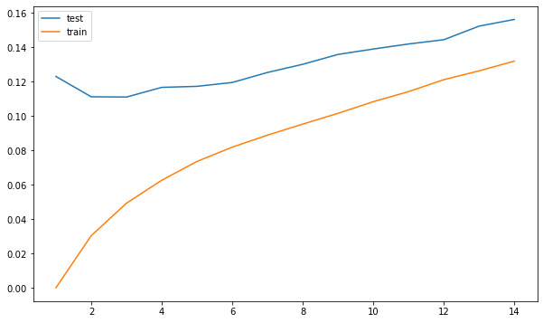

```python
kltest = []
vltest = []
for k, v in knn_many_split.items():
    kltest.append(k)
    vltest.append(knn_many_split[k][1])

kltrain = []
vltrain = []

for k, v in knn_many_split.items():
    kltrain.append(k)
    vltrain.append(knn_many_split[k][0])

# Plotting k vs error
plt.figure(figsize=(10,6))
plt.plot(kltest,vltest, label = 'test' )
plt.plot(kltrain,vltrain, label = 'train')
plt.legend()
plt.show()
```

```python
#define knn model
knn=KNeighborsRegressor(n_neighbors=3)
```

```python
#fitting data to the KNN model
knn.fit(X_train,y_train['price_log'])
```

```
KNeighborsRegressor(n_neighbors=3)
```

```python
#checking the performance of knn model
get_model_score(knn)
```

```
R-sqaure on training set :  0.9318542903467357
R-square on test set :  0.8123035446674083
RMSE on training set :  2.9165573958469717
RMSE on test set :  4.828447045547348
```

```
[0.9318542903467357, 0.8123035446674083, 2.9165573958469717, 4.828447045547348]
```

Observations

- neighbors at 3 had the best result in terms of R^2 and RMSE compared to other numbers

### **Insights**

#### **Refined insights**:

What are the most meaningful insights from the data relevant to the problem?

- 'Model', 'New_price', 'Location', 'Fuel_Type', 'Engine', 'Owner_Type', 'Power', 'Transmission', 'kilometers_driven_log', 'Brand', 'Year' seem to be the most important variables when predicting price.

#### **Comparison of various techniques and their relative performance**:

How do different techniques perform? Which one is performing relatively better? Is there scope to improve the performance further?

#### **Proposal for the final solution design**:

What model do you propose to be adopted? Why is this the best solution to adopt?

- We want explainability when it comes to determining the price of a vehicle. If it's hard to explain it is likely a hard sell for the customer as well. The more we can explain it well to our internal stakeholders the more likely it would be to explain to our customers and successfully make a sale to them
- Hence, using the linear regression analysis and making several improvements on it could help
- We could do this by adding some variables which would need to be meaningful as opposed to adding variables just for the sake of adding variables

**FEEDBACK**

1. Refined Insights

The most meaningful insights from the data relevant to the problem

Areas that you have done well: Good job stating the below insights from model implementation: Good job on identifying the most significant variables that looked significant in EDA and are also important post modelling. Good job on listing of important variable with Linear Regression includes - New_price, Location, Fuel_Type, Owner_Type, Transmission. Good job on listing of important variable with Decision tree and Random Forest includes - Power, Engine, Year, Mileage. 3/3

1. Comparison of various techniques and their relative performance

How do different techniques perform? Which one is performing relatively better? Is there scope to improve the performance further?

Areas performed well: Best model has 85%+ R Squared. Good job on Trying different models.There is very little overfitting in the tuned model. Good job on choosig the best model and it includes all the important variables and reason behind it was provided. 4/4

1. Proposal for the final solution design

What model do you propose to be adopted? Why is this the best solution to adopt?

Areas performed well: Good job on calculating Rsquare or RMSE as a metric along with drivers of the model. Best model inlcudes all the important variables Reason for choosing the best model

Areas of improvement: Failed to mention the the tradeoff between model performance and model interpretability Failed to mention about how the selected model solves the problem? 2.5/3